[figure not shown]

# Regressão Linear Simples no R

Temos que a Regressão Linear Simples é um modelo que contém uma única variável independente.

# O que vamos executar?

- Verificar os pressupostos da regressão linear: relação linear entre as variáveis, normalidade, homocedasticidade, ausência de outliers, independência dos resíduos;
- Montar e interpretar o modelo de regressão linear simples;
- Montar um gráfico incluindo a equação da reta;
- Descrever os resultados.

# Situação problema

O “Banco de Dados 11.csv” contém informações de 187 CDs comercializados por uma gravadora. Verifique se o gasto em publicidade é capaz de prever a venda de CDs. Descreva os resultados de maneira apropriada.[^1]

# Efetuando a Análise

É necessário seguir alguns passos importantes.

## Passo 1: Carregar os pacotes de dados

```r
if(!require(dplyr)) install.packages("dplyr")
library(dplyr)
if(!require(car)) install.packages("car")
library(car)
if(!require(data.table)) install.packages("data.table")
library(data.table)
if(!require(rstatix)) install.packages("rstatix")
library(rstatix)
if(!require(lmtest)) install.packages("lmtest")
library(lmtest)
if(!require(rlang)) install.packages("rlang")
library(rlang)
if(!require(ggplot2)) install.packages("ggplot2", type = "binary")
library(ggplot2)
if(!require(ggpmisc)) install.packages("ggpmisc")
library(ggpmisc)
```

## Passo 2: Carregar o banco de dados

Detalhe importante: selecionar o diretório de trabalho via *Session/Set Working Directory/Choose Directory*.

```r
## Incluindo os dados
dados <- read.csv2('Banco de Dados 11.csv',
                    fileEncoding = "latin1")
glimpse(dados)
```

```
## Rows: 187
## Columns: 2
## $ Publicidade <dbl> 985.69, 1445.56, 1188.19, 574.51, 568.95, 471.81, 537.35, ~
## $ Vendas      <int> 120, 360, 270, 220, 170, 70, 210, 200, 70, 150, 190, 240, ~
```

## Passo 3: Verificar os pressupostos

Primeiramente verificamos a relação de linearidade entre as variáveis dependente e independente. Dessa forma, o modelo analisará o impacto da publicidade sobre o volume de vendas, logo: `VD = Vendas`, e `VI = Publicidade`.

A primeira coisa que podemos fazer para avaliar essa relação é um gráfico, a fim de visualizarmos como que as variáveis se relacionam.

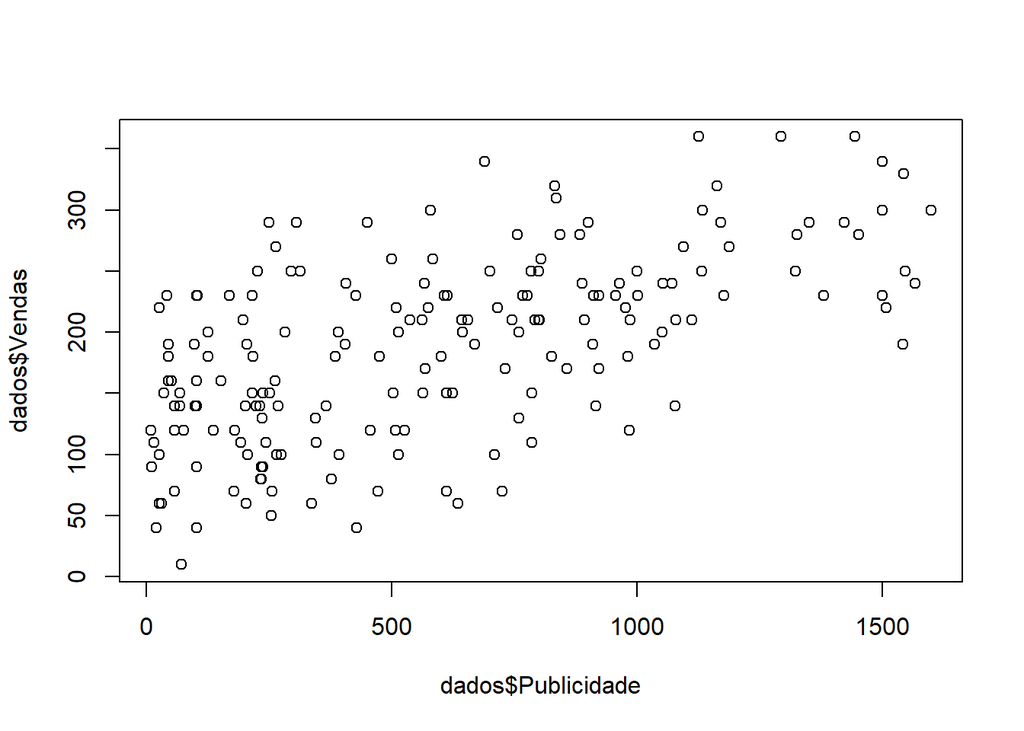

```r
# Relação linear entre VD e VI:
plot(dados$Publicidade, dados$Vendas)
```

Somente por esse gráfico já podemos ver que, apesar da nuvem de pontos, a tendência segue um crescimento linear, o que nos permite observar que o pressuposto de linearidade dos parâmetros pode estar sendo atendido.

No entanto, para todas as outras coisas que precisamos ainda verificar, faremos isso ou sobre os resíduos do modelo, ou em cima do modelo em si (gráficos do modelo). O R gera quatro gráficos a partir de um modelo de regressão linear simples, que nos permite visualmente identificar se alguns pressupostos estão sendo atendidos. Veremos abaixo como gerar esses gráficos, e o que podemos extrair de informações a partir do que for plotado.[^2]

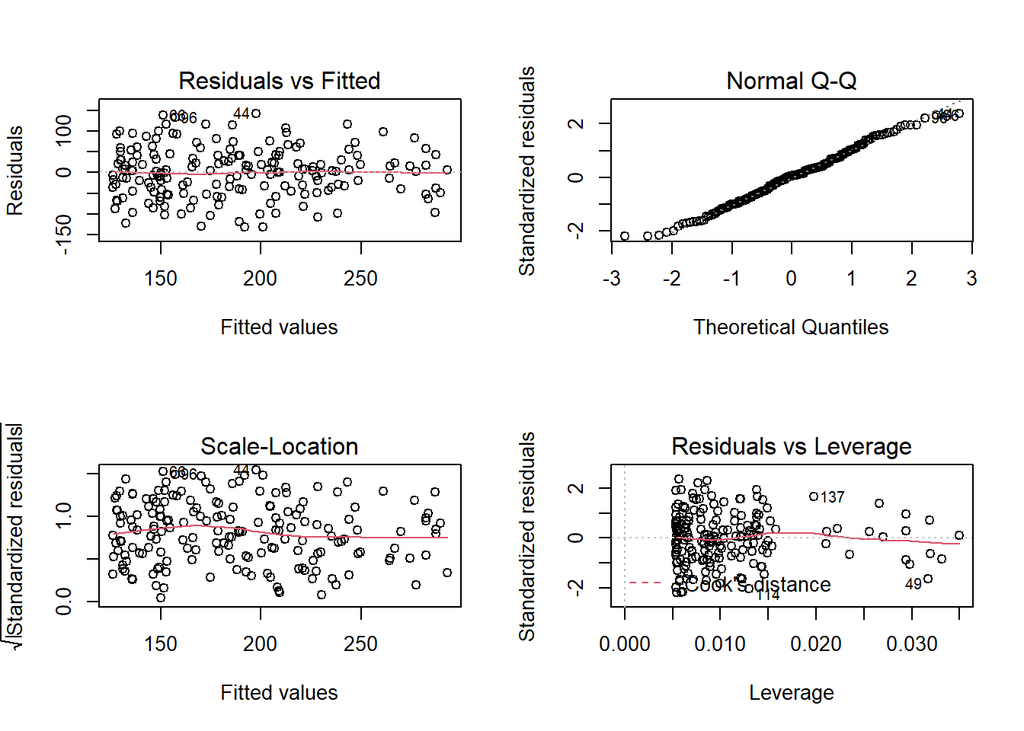

```r
# Construção do modelo
mod <- lm(Vendas ~ Publicidade, dados)

# Análise gráfica
par(mfrow = c(2,2)) # inserindo um quadro juntando os quatro gráficos que serão gerados
plot(mod)
```

```r
par(mfrow = c(1,1)) # retomando a apresentação dos gráficos em unidade
```

- O primeiro gráfico entitulado **“Residuals vs Fitted”** aponta os resíduos do modelo comparados com os valores previstos. Podemos analisar duas coisas: 1. a linearidade do modelo, observando a linha vermelha disposta no gráfico (se ela tiver ou não um segmento horizontal, coincidindo com a linha pontilhada), e 2. a homocedasticidade, dada pela homogeneidade de variâncias (distribuição de resíduos disposta de maneira constante ao longo do gráfico). Nesse caso, podemos ver que tanto o pressuposto de linearidade quanto de homocedasticidade estão sendo atendidos.
- O segundo gráfico entitulado **“Normal Q-Q”** nos permite ver se os resíduos seguem uma distribuição normal. Trata-se de um gráfico `qqplot`, trazendo no eixo y os resíduos padronizados e no eixo x os resíduos teóricos, que seriam os resíduos esperados caso a distribuição fosse normal. Caso os resíduos apresentem distribuição normal, precisariam aparecer concentrados sobre a linha pontilhada (padrão), o que visualmente podemos verificar que acontece com nosso modelo, nos permitindo entender que o pressuposto de normalidade está sendo atendido.
- O terceiro gráfico entitulado **“Scale Location”** é o mais recomendado para avaliar pressupostos de homocedasticidade pois caso seja atendido, podemos ver a linha em vermelho no gráfico tendendo a um formato horizontal. No gráfico temos os valores distribuídos, trazendo no eixo y a raiz quadrada dos resíduos padronizados e no eixo x também os valores esperados.
- O quarto gráfico entitulado **“Residuals vs Leverage”** é o que nos permite pensar em resíduo relacionado a existência de outliers. Então este é um gráfico para a gente pensar se há outliers e se existem pontos de alavancagem. Lembrando que temos um pressuposto na regressão é a ausência de outlers, mas nesse caso o que preocupa a análise são os pontos discrepantes de alavancagem (pontos tão distantes que podem influenciar a estimação do modelo). O gráfico apresenta uma linha tracejada apontando o intervalo da *Cook’s distance* e na alavancagem (*Leverage*), de modo que se o ponto estiver fora da linha vermelha, este será um ponco com o qual devemos nos preocupar.

Tendo isso em vista, verificamos que os pressupostos de linearidade nos parâmetros, homocedasticidade, distribuição normal dos resíduos (normalidade) e ausência de outliers de alavancagem (*Leverage*) foram atendidos.

## Passo 4: Analisando os pressupostos pelos testes

Apesar de a análise dos pressupostos se bastar pelos resultados gerados em gráficos, conforme visto anteriormente, é sabido que em estatística precisamos demonstrar os resultados partindo de testes para cada análise de interesse. Nesse caso, verificaremos os pressupostos de Normalidade, ausência de outliers, independência dos resíduos e homogeneidade a partir dos respectivos testes: `shapiro.test` para normalidade dos resíduos, `rstandard` para verificação dos outliers, `durbinWatsonTest` (Teste Durbin-Watson) para independência dos resíduos, e `bptest` para análise da homocedasticidade.

```r
# Normalidade dos resíduos
shapiro.test(mod$residuals)
```

```
##
##  Shapiro-Wilk normality test
##
## data:  mod$residuals
## W = 0.99193, p-value = 0.3856
```

A interpretação das hipóteses do teste de shapiro para normalidade dos resíduos serão dadas por:

- H<sub>0</sub>: Distribuição dos Dados = Normal → p > 0,05
- H<sub>1</sub>: Distribuição dos Dados ≠ Normal → p ≤ 0,05

Onde o resultado aporta para aceitarmos a hipótese nula, com a normalidade da distribuição dos resíduos sendo atendida.

```r
# Outliers nos resíduos
summary(rstandard(mod))
```

```
##       Min.    1st Qu.     Median       Mean    3rd Qu.       Max.
## -2.1981347 -0.7064734  0.0392186 -0.0000075  0.6828619  2.3753897
```

Nesse caso temos uma situação onde os outliers não fogem do intervalo de -3 e +3, de modo que o modelo não possui valores que estejam fora do padrão de distribuição dos resíduos.

```r
# Independência dos resíduos (Durbin-Watson)
durbinWatsonTest(mod)
```

```
##  lag Autocorrelation D-W Statistic p-value
##    1     -0.01039454       1.98891    0.92
##  Alternative hypothesis: rho != 0
```

- H<sub>0</sub>: Correlação entre os resíduos = zero (não existe correlação) → p > 0,05
- H<sub>1</sub>: Correlação entre os resíduos ≠ zero (existe correlação) → p ≤ 0,05

Com isso, verificamos que o pressuposto da independência entre os resíduos também é atendido.

```r
# Homogeneidade (Breusch-Pagan)
bptest(mod)
```

```
##
##  studentized Breusch-Pagan test
##
## data:  mod
## BP = 1.4245, df = 1, p-value = 0.2327
```

Interpretamos esse teste de maneira semelhante como fazemos com o teste de Levene, onde a hipótese nula diz que há homocedasticidade, enquanto que a alternativa diz que não há.

- H<sub>0</sub>: Há homocedasticidade → p > 0,05
- H<sub>1</sub>: Não há homocedasticidade → p ≤ 0,05

Com isso, verificamos que o pressuposto da homogeneidade também é atendido.

## Passo 5: Análise do modelo

Verificados os pressupostos, partimos agora para a análise do modelo, onde encontramos os estimadores dos parâmetros Beta, assim como as estatísticas T e de `p-value`.

```r
summary(mod)
```

```
##
## Call:
## lm(formula = Vendas ~ Publicidade, data = dados)
##
## Residuals:
##      Min       1Q   Median       3Q      Max
## -131.840  -42.283    2.344   40.945  142.455
##
## Coefficients:
##              Estimate Std. Error t value Pr(>|t|)
## (Intercept) 125.17951    7.43140   16.84   <2e-16 ***
## Publicidade   0.10495    0.01021   10.28   <2e-16 ***
## ---
## Signif. codes:  0 '***' 0.001 '**' 0.01 '*' 0.05 '.' 0.1 ' ' 1
##
## Residual standard error: 60.14 on 185 degrees of freedom
## Multiple R-squared:  0.3634, Adjusted R-squared:   0.36
## F-statistic: 105.6 on 1 and 185 DF,  p-value: < 2.2e-16
```

Os pressupostos da estatística de `p-value` sobre os parâmetros (intercepto e beta1) nos permite avaliar se há interferência em eventual alteração nos valores das variáveis independentes sobre a variável analisada. E para um alfa de 5% (padrão de nossas análises), temos que:

- H<sub>0</sub>: Coeficiente = 0 → p > 0,05
- H<sub>1</sub>: Coeficiente ≠ 0 → p ≤ 0,05

Logo, percebemos que o coeficiente da variável `Publicidade` pode ser interpretado, e tem um impacto sobre a variável `Vendas`.

Acerca do valor apontado para R<sup>2</sup>, temos o quanto que o modelo explica mudanças na variável dependente (36%).

Esse resultado apresenta também uma estatística T, condicionado aos graus de liberdade `df = 185`, apontando `p-value` que nos permite rejeitar a hipótese nula que diz que as vendas estariam sempre na média, de modo que o investimento em publicidade não alteraria em nada os resultados esperados.

- H<sub>0</sub>: O modelo criado não prevê alteração nas vendas = 0 → p > 0,05
- H<sub>1</sub>: O modelo criado prevê alteração nas vendas ≠ 0 → p ≤ 0,05

## Passo 6: Gráfico de dispersão

Para melhor visualizar o modelo de regressão linear simples, faremos um gráfico para visualizar o comportamento dos dados analisados, descrevendo a função gerada.

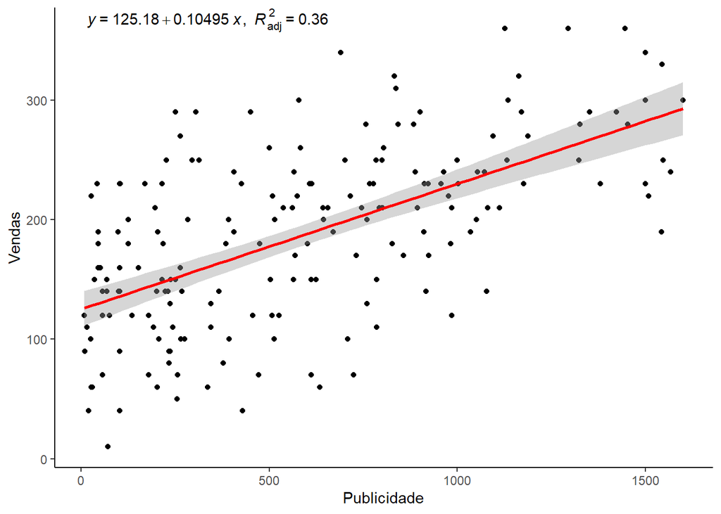

```r
ggplot(data = dados, mapping = aes(x = Publicidade, y = Vendas)) +
  geom_point() +
  geom_smooth(method = "lm", col = "red") +
  stat_poly_eq(aes(label = paste(after_stat(eq.label), after_stat(adj.rr.label),
                                 sep = "*plain(\",\")~~")),
               label.x = 0.05, label.y = 400,
               parse = TRUE, coef.digits = 5) +
  theme_classic()
```

# Resultado

A regressão linear simples mostrou que o investimento em publicidade está associado a um aumento da venda de CDs. A cada R$ 1,00 gasto em publicidade, a venda de CDs aumenta, em média, 0,1.

[^1]: Curso de Estatística Aplicada no R, Professora Fernanda Peres: [link](https://www.youtube.com/playlist?list=PLOw62cBQ5j9VE9X4cCCfFMjW_hhEAJUhU)
[^2]: Data Library Virginia: [link](https://data.library.virginia.edu/diagnostic-plots/)